# Part II - PISA 2012

## by Aldair Mendoza

## Investigation Overview

The main features of interest are student score performance on math, reading, and science. Essentially finding what variables affect the overall score of students and their performance at school.

**First: When the parent education level is the highest. It is clear that the better is the score of a student.**

**Second: When both parents are present, it is clear that the score is better rather than single parenthood.**

## Dataset Overview

PISA 2012 is an study developed by the OECD, the data contains the skills of 15-year-old school students around the world. The study mainly assesses students’ mathematics, science, and reading skills. The data also contains information on students’ background and their schools.This dataset, PISA 2012, has relevant data on 485,490 students around the world.

## What are the top 10 countries with the best student overall scores?

**China-Shanghai has the best score on the three subjects.**

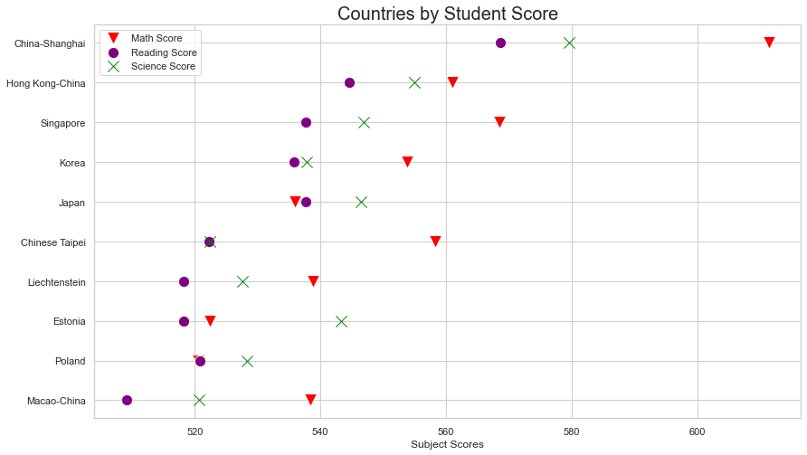

## Does parent education level affect the overall score of students?

**When the parent education level is the highest. It is clear that the better is the score of a student.**

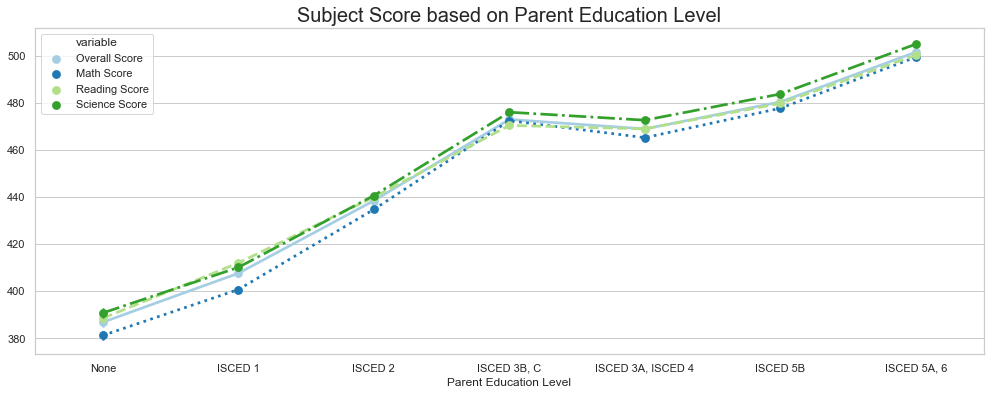

## Can the parenthood impact the overall score of students?

**There is no significant correlation between hours of with parents and overall score. However, then there is a positive impact on overall score when both parents are present rather than single parent.**

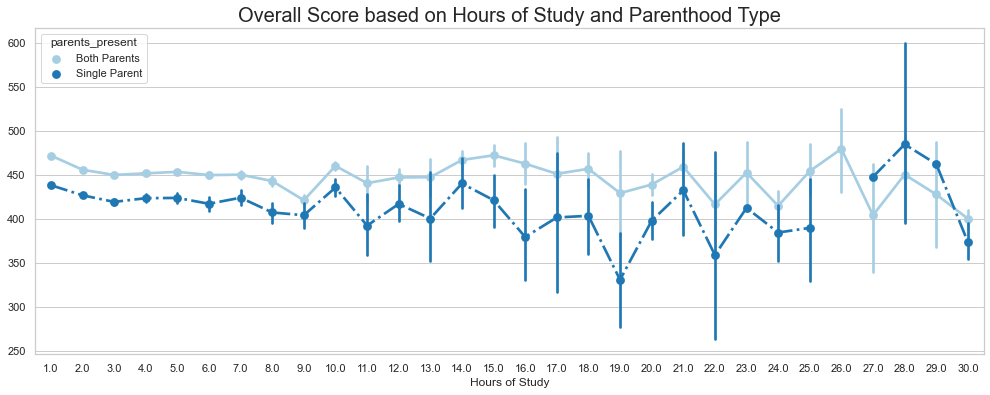

## Do parenthood influence on overall score?

**Yes. When both parents are present, it is clear that the score is better rather than single parenthood.**

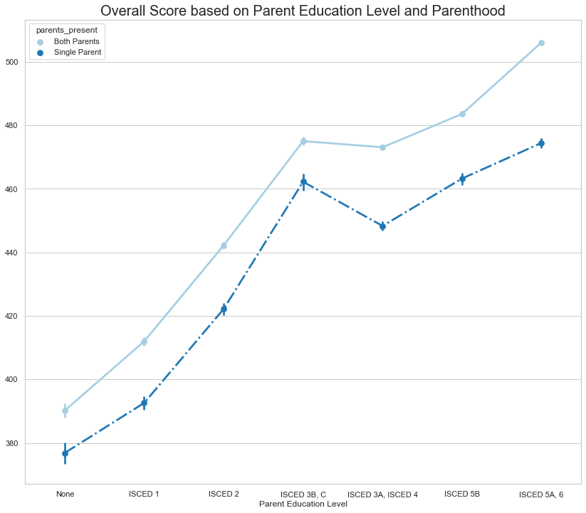